# A1 - Preproceso de datos

Yésica Fernández

2022-06-07

Antes de empezar con el preprocesado de datos, vamos a cargar los paquetes necesarios para la realización del ejercicio.

```r
# https://cran.r-project.org/web/packages/dplyr/index.html
if (!require('dplyr')) install.packages('dplyr'); library('dplyr')
# https://cran.r-project.org/web/packages/stringr/index.html
if (!require('dplyr')) install.packages('stringr'); library('stringr')
# https://cran.r-project.org/web/packages/ggplot2/index.html
if (!require('ggplot2')) install.packages('ggplot2'); library('ggplot2')
# https://cran.r-project.org/web/packages/VIM/index.html
if (!require('VIM')) install.packages('VIM'); library('VIM')
# https://cran.r-project.org/web/packages/psych/index.html
if (!require('psych')) install.packages('psych'); library('psych')
```

# 1.- Carga del archivo

En primer lugar, se carga el csv de datos para poder trabajar con el.

```r
CensusIncomedataset <- read.csv("CensusIncomedataset.csv", sep = ";", stringsAsFactors = TRUE)
```

Una vez cargado el dataset, se analizan los tipos de datos con los que se han cargado las variables.

```r
str(CensusIncomedataset)
```

```
## 'data.frame':    32560 obs. of  14 variables:
##  $ CS_ID         : Factor w/ 32553 levels "CS1","CS10","CS100",..: 1 11112 22222 25894 27005 28116 29226 30335 31444 2 ...
##  $ age           : int  50 38 53 28 37 49 52 31 42 37 ...
##  $ workclass     : Factor w/ 4 levels " Government",..: 4 3 3 3 3 3 4 3 3 3 ...
##  $ fnlwgt        : int  77516 83311 215646 234721 338409 284582 160187 209642 45781 159449 ...
##  $ education_num : int  13 9 7 13 14 5 9 14 13 10 ...
##  $ marital_status: Factor w/ 5 levels " Divorced"," Married",..: 2 1 2 2 2 2 2 4 2 2 ...
##  $ relationship  : Factor w/ 6 levels "Husband","Not-in-family",..: 2 1 2 1 6 6 2 1 2 1 ...
##  $ occupation    : Factor w/ 6 levels " Blue-Collar",..: 6 1 1 3 6 5 6 3 6 6 ...
##  $ race          : Factor w/ 5 levels " Amer-Indian-Eskimo",..: 5 5 3 3 5 3 5 5 5 3 ...
##  $ sex           : Factor w/ 8 levels " F"," Fem"," female",..: 6 6 6 2 2 2 6 2 6 6 ...
##  $ capital_gain  : int  2174 0 0 0 0 0 0 0 14084 5178 ...
##  $ capital_loss  : int  0 0 0 0 0 0 0 0 0 0 ...
##  $ hours_per_week: Factor w/ 181 levels "1 h","1,5 h",..: 10 69 70 69 70 15 79 92 69 149 ...
##  $ income        : Factor w/ 4103 levels "0,1 Milers d'euros",..: 2 2509 2308 1517 1 1463 3 749 3291 2224 ...
```

Se puede ver que existen 5 variables de tipo “int” y 9 variables de tipo factor, que son texto. Vamos a ver un resumen de los valores que contiene cada variable.

```r
summary(CensusIncomedataset)
```

```
##      CS_ID            age                  workclass         fnlwgt
##  CS23654:    2   Min.   : 17.00    Government   : 4349   Min.   :  12285
##  CS624  :    2   1st Qu.: 28.00    Other/Unknown: 1855   1st Qu.: 117824
##  CS7163 :    2   Median : 37.00    Private      :22692   Median : 178356
##  CS7453 :    2   Mean   : 38.58    Self-Employed: 3657   Mean   : 189775
##  CS8017 :    2   3rd Qu.: 48.00   NA's          :    7   3rd Qu.: 237046
##  CS8087 :    2   Max.   :650.00                          Max.   :1484705
##  (Other):32548   NA's   :7
##  education_num      marital_status          relationship
##  Min.   : 1.00    Divorced : 4443   Husband       :13192
##  1st Qu.: 9.00    Married  :15417   Not-in-family : 8303
##  Median :10.00    Separated: 1025   Other-relative:  981
##  Mean   :10.08    Single   :10682   Own-child     : 5067
##  3rd Qu.:12.00    Widowed  :  993   Unmarried     : 3444
##  Max.   :16.00                      Wife          : 1566
##  NA's   :7                          NA's          :    7
##           occupation                     race            sex
##   Blue-Collar  :10060    Amer-Indian-Eskimo:  311    Male  :19789
##   Other/Unknown: 1850    Asian-Pac-Islander: 1039    Female: 8771
##   Professional : 4139    Black             : 3123    female: 1100
##   Sales        : 3649    Other             :  271    male  : 1100
##   Service      : 5021    White             :27809    F     :  500
##   White-Collar : 7834   NA's               :    7    m     :  500
##  NA's          :    7                               (Other):  800
##   capital_gain    capital_loss     hours_per_week                   income
##  Min.   :    0   Min.   :   0.00   40,5 h : 8325   52,37 Milers d'euros:   32
##  1st Qu.:    0   1st Qu.:   0.00   40 h   : 6891   52,71 Milers d'euros:   32
##  Median :    0   Median :   0.00   50,5 h : 1575   54,02 Milers d'euros:   30
##  Mean   : 1077   Mean   :  87.31   50 h   : 1244   54,35 Milers d'euros:   29
##  3rd Qu.:    0   3rd Qu.:   0.00   45,5 h : 1039   52,27 Milers d'euros:   28
##  Max.   :99999   Max.   :4356.00   60,5 h :  830   53,76 Milers d'euros:   28
##                                    (Other):12656   (Other)             :32381
```

En el resumen anterior, se puede observar para las variables numéricas el mínimo, máximo, la media, la mediana, el primer quartil y el tercer cuartil. En cuanto a las variables de tipo factor, se observa cuantas apariciones existen para cada posible valor de la variable.

# 2.- Obtención del dataset para realizar el estudio

En primer lugar, se van a eliminar las variables que no se quieren utilizar en el estudio: **fnlwgt, capital_gain y capital_loss**.

```r
eliminar <- c("fnlwgt", "capital_gain", "capital_loss")
CensusIncomedatasetMod <- CensusIncomedataset[ , !names(CensusIncomedataset) %in% eliminar]
```

Ahora, se eliminarán los registros con más de 5 valores NA, pues son registros incompletos que podrían perjudicarnos a la hora de analizar el dataset.

```r
CensusIncomedatasetMod <- CensusIncomedatasetMod[apply(X = is.na(CensusIncomedatasetMod), MARGIN = 1, FUN = sum) <=5,]
```

Se puede ver resumen del dataset para observar cuantos valores nulos nos quedan por columna:

```r
summary(CensusIncomedatasetMod)
```

```
##      CS_ID            age                  workclass     education_num
##  CS23654:    2   Min.   : 17.00    Government   : 4349   Min.   : 1.00
##  CS624  :    2   1st Qu.: 28.00    Other/Unknown: 1855   1st Qu.: 9.00
##  CS7163 :    2   Median : 37.00    Private      :22692   Median :10.00
##  CS7453 :    2   Mean   : 38.58    Self-Employed: 3657   Mean   :10.08
##  CS8017 :    2   3rd Qu.: 48.00                          3rd Qu.:12.00
##  CS8087 :    2   Max.   :650.00                          Max.   :16.00
##  (Other):32541
##     marital_status          relationship            occupation
##   Divorced : 4442   Husband       :13192    Blue-Collar  :10060
##   Married  :15413   Not-in-family : 8303    Other/Unknown: 1850
##   Separated: 1025   Other-relative:  981    Professional : 4139
##   Single   :10680   Own-child     : 5067    Sales        : 3649
##   Widowed  :  993   Unmarried     : 3444    Service      : 5021
##                     Wife          : 1566    White-Collar : 7834
##
##                   race            sex        hours_per_week
##   Amer-Indian-Eskimo:  311    Male  :19787   40,5 h : 8323
##   Asian-Pac-Islander: 1039    Female: 8767   40 h   : 6889
##   Black             : 3123    female: 1100   50,5 h : 1575
##   Other             :  271    male  : 1100   50 h   : 1244
##   White             :27809    F     :  500   45,5 h : 1039
##                               m     :  499   60,5 h :  829
##                              (Other):  800   (Other):12654
##                   income
##  52,37 Milers d'euros:   32
##  52,71 Milers d'euros:   32
##  54,02 Milers d'euros:   30
##  54,35 Milers d'euros:   29
##  52,27 Milers d'euros:   28
##  53,76 Milers d'euros:   28
##  (Other)             :32374
```

Se observa en el resumen de los datos que ya no hay variables con valores nulos. A continuación, se van a crear nuevas variables en función de las disponibles. Se crea la variable **education_cat** en función de la variable **education_num**. Los valores que tomará esta variable son los siguientes:

- **primaria** si education_num < 7
- **secundaria** si education_num entre 7 y 9
- **universitaria** si education_num entre 10 y 13
- **postuniversitaria** si education_num mayor que 13

```r
CensusIncomedatasetMod$education_cat <- factor(ifelse(CensusIncomedatasetMod$education_num < 7, "primaria", ifelse(CensusIncomedatasetMod$education_num >= 7 & CensusIncomedatasetMod$education_num <= 9, "secundaria", ifelse(CensusIncomedatasetMod$education_num >= 10 & CensusIncomedatasetMod$education_num <= 13, "universitaria", "postuniversitara"))))
```

Por último, se quiere cambiar el nombre de la variable **sex** por **gender**.

```r
CensusIncomedatasetMod <- CensusIncomedatasetMod %>% rename(gender = sex)
```

Se imprime un resumen del dataset para ver como se encuentra en el punto actual después de las modificaciones.

```r
summary(CensusIncomedatasetMod)
```

```
##      CS_ID            age                  workclass     education_num
##  CS23654:    2   Min.   : 17.00    Government   : 4349   Min.   : 1.00
##  CS624  :    2   1st Qu.: 28.00    Other/Unknown: 1855   1st Qu.: 9.00
##  CS7163 :    2   Median : 37.00    Private      :22692   Median :10.00
##  CS7453 :    2   Mean   : 38.58    Self-Employed: 3657   Mean   :10.08
##  CS8017 :    2   3rd Qu.: 48.00                          3rd Qu.:12.00
##  CS8087 :    2   Max.   :650.00                          Max.   :16.00
##  (Other):32541
##     marital_status          relationship            occupation
##   Divorced : 4442   Husband       :13192    Blue-Collar  :10060
##   Married  :15413   Not-in-family : 8303    Other/Unknown: 1850
##   Separated: 1025   Other-relative:  981    Professional : 4139
##   Single   :10680   Own-child     : 5067    Sales        : 3649
##   Widowed  :  993   Unmarried     : 3444    Service      : 5021
##                     Wife          : 1566    White-Collar : 7834
##
##                   race           gender      hours_per_week
##   Amer-Indian-Eskimo:  311    Male  :19787   40,5 h : 8323
##   Asian-Pac-Islander: 1039    Female: 8767   40 h   : 6889
##   Black             : 3123    female: 1100   50,5 h : 1575
##   Other             :  271    male  : 1100   50 h   : 1244
##   White             :27809    F     :  500   45,5 h : 1039
##                               m     :  499   60,5 h :  829
##                              (Other):  800   (Other):12654
##                   income               education_cat
##  52,37 Milers d'euros:   32   postuniversitara: 2712
##  52,71 Milers d'euros:   32   primaria        : 2644
##  54,02 Milers d'euros:   30   secundaria      :12106
##  54,35 Milers d'euros:   29   universitaria   :15091
##  52,27 Milers d'euros:   28
##  53,76 Milers d'euros:   28
##  (Other)             :32374
```

# 3.- Duplicación de códigos

En este apartado se va a verificar la consistencia de la variable CS_ID, el identificador de cada registro. En primer lugar, se detectan si existen duplicados.

```r
Duplicados <- CensusIncomedatasetMod[duplicated(CensusIncomedatasetMod$CS_ID), ]
Duplicados
```

```
##         CS_ID age      workclass education_num marital_status   relationship
## 624     CS624  47        Private             5        Married        Husband
## 7163   CS7163  39        Private            15        Married  Not-in-family
## 7453   CS7453  31        Private            10       Divorced        Husband
## 8017   CS8017  33        Private            10      Separated Other-relative
## 8087   CS8087  30        Private            11       Divorced      Unmarried
## 9197   CS9197  47  Other/Unknown            13        Married  Not-in-family
## 23654 CS23654  34  Self-Employed            13       Divorced        Husband
##           occupation   race  gender hours_per_week               income
## 624      Blue-Collar  White       m         40,5 h 54,52 Milers d'euros
## 7163    Professional  White  Female           60 h 44,66 Milers d'euros
## 7453           Sales  White  Female           35 h 42,98 Milers d'euros
## 8017    White-Collar  White  Female         40,5 h 39,73 Milers d'euros
## 8087    White-Collar  White    Male         40,5 h 52,28 Milers d'euros
## 9197   Other/Unknown  White    Male         36,5 h 53,03 Milers d'euros
## 23654    Blue-Collar  White    Male         60,5 h 50,69 Milers d'euros
##          education_cat
## 624           primaria
## 7163  postuniversitara
## 7453     universitaria
## 8017     universitaria
## 8087     universitaria
## 9197     universitaria
## 23654    universitaria
```

Una vez que se tienen los códigos duplicados, se obtiene el máximo valor de CS_ID para ver con que valor reemplazar estos duplicados.

```r
max(as.integer(substring(CensusIncomedatasetMod$CS_ID, first = 3)))
```

```
## [1] 32560
```

Por lo tanto, como se tienen 7 duplicados, habrá que reemplazarlos con los siguientes valores: CS32561, CS32562, CS32563, CS32564, CS32565, CS32566 y CS32567. En primer lugar, se busca otro campo para poder diferenciar estos registros y reemplazar el valor sólo en el duplicado.

```r
CensusIncomedatasetMod[CensusIncomedatasetMod$CS_ID %in% (Duplicados$CS_ID), ]
```

```
##         CS_ID age      workclass education_num marital_status   relationship
## 623     CS624  29        Private            11        Married      Unmarried
## 624     CS624  47        Private             5        Married        Husband
## 7162   CS7163  42     Government             9       Divorced      Unmarried
## 7163   CS7163  39        Private            15        Married  Not-in-family
## 7452   CS7453  53        Private            11        Married      Own-child
## 7453   CS7453  31        Private            10       Divorced        Husband
## 8016   CS8017  20        Private            10         Single        Husband
## 8017   CS8017  33        Private            10      Separated Other-relative
## 8086   CS8087  31        Private            11       Divorced      Own-child
## 8087   CS8087  30        Private            11       Divorced      Unmarried
## 9196   CS9197  46        Private             9         Single  Not-in-family
## 9197   CS9197  47  Other/Unknown            13        Married  Not-in-family
## 23653 CS23654  43        Private             9        Married      Own-child
## 23654 CS23654  34  Self-Employed            13       Divorced        Husband
```

[output cut: 30 more lines]

Se observa que con la variable “edad” podemos diferenciar los registros, por lo que se utilizará para filtrar a la hora de realizar la sustitución del identificador.

```r
CensusIncomedatasetMod <- CensusIncomedatasetMod %>% mutate(CS_ID = case_when(
    CS_ID == "CS624" & age == 47 ~ "CS32561",
    CS_ID == "CS7163" & age == 39 ~ "CS32562",
    CS_ID == "CS7453" & age == 31 ~ "CS32563",
    CS_ID == "CS8017" & age == 33 ~ "CS32564",
    CS_ID == "CS8087" & age == 30 ~ "CS32565",
    CS_ID == "CS9197" & age == 47 ~ "CS32566",
    CS_ID == "CS23654" & age == 34 ~ "CS32567",
    TRUE ~ as.character(CS_ID)
  )
)
```

Se vuelve a comprobar si existen duplicados para ver si se realizó la sustitución de valores correctamente.

```r
CensusIncomedatasetMod[duplicated(CensusIncomedatasetMod$CS_ID), ]
```

```
##  [1] CS_ID          age            workclass      education_num  marital_status
##  [6] relationship   occupation     race           gender         hours_per_week
## [11] income         education_cat
## <0 rows> (or 0-length row.names)
```

# 4.- Normalización de datos cualitativos

## 4.1.- Eliminación de espacios en blanco

Se ha observado que existen espacios en blanco al inicio de los valores en las variables cualitativas. Por tanto, es necesario eliminar estos espacios en blancos. Observamos alguno de estos casos:

```r
head(grep(pattern = "^\\s", CensusIncomedatasetMod$marital_status, value=T))
```

```
## [1] " Married"  " Divorced" " Married"  " Married"  " Married"  " Married"
```

Se procede a la eliminación de los espacios en blanco al inicio y al final de todos los valores del dataset.

```r
CensusIncomedatasetMod <- as.data.frame(lapply(CensusIncomedatasetMod,str_trim), stringsAsFactors = TRUE)
```

Una vez eliminadas, se comprueba con el ejemplo anterior que ya no existen coincidencias con el patrón.

```r
head(grep(pattern = "^\\s", CensusIncomedatasetMod$marital_status, value=T))
```

```
## character(0)
```

## 4.2.- Marital-Status

Se van a cambiar las categorías de la variable marital status actuales por otras que ocupen un carácter. Los valores que se asignarán a la variable marital_status son: **M** por Married, **S** por Single, **X** por Separated, **D** por Divorced, **W** por Widowed.

```r
CensusIncomedatasetMod <- CensusIncomedatasetMod %>% mutate(marital_status = factor(case_when(
    marital_status == "Married" ~ "M",
    marital_status == "Single" ~ "S",
    marital_status == "Separated"  ~ "X",
    marital_status == "Divorced"  ~ "D",
    marital_status == "Widowed"  ~ "W"
  ))
)
```

Ahora se va a representar gráficamente la distribución de valores de la variable.

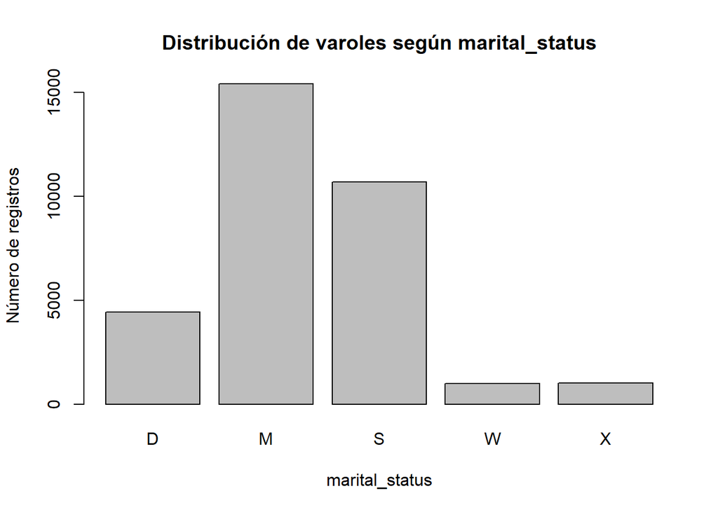

```r
plot(x=CensusIncomedatasetMod$marital_status, main ="Distribución de varoles según marital_status", xlab = "marital_status", ylab = "Número de registros")
```

## 4.3.- Género

En primer lugar, se va revisar la consistencia de la variable **gender**. Por lo tanto, vamos a observar que valores contiene esta variable.

```r
summary(CensusIncomedatasetMod$gender)
```

```
##      F    Fem female Female      m      M   male   Male
##    500    400   1100   8767    499    400   1100  19787
```

Se observa que los datos no son consistentes. Para el género femenino la variable puede tomar valores **F**, **Fem**, **female** o **Female** y para el génermo másculino puede tomar los valores **m**, **M**, **male** y **Male**. Por lo tanto, se va a unificar estos valores de tal manera que el género femenino siempre se represente con **f** y el género masculino con **m**.

```r
CensusIncomedatasetMod <- CensusIncomedatasetMod %>% mutate(gender = factor(case_when(
    gender == "f"  | gender == "F" | gender == "Female" | gender == "female" | gender == "Fem" ~ "f",
    gender == "m" | gender == "M" | gender == "Male" | gender == "male" ~ "m"
  ))
)
```

Para ver el cambio, se va a representar gráficamente la distribución de valores de la variable.

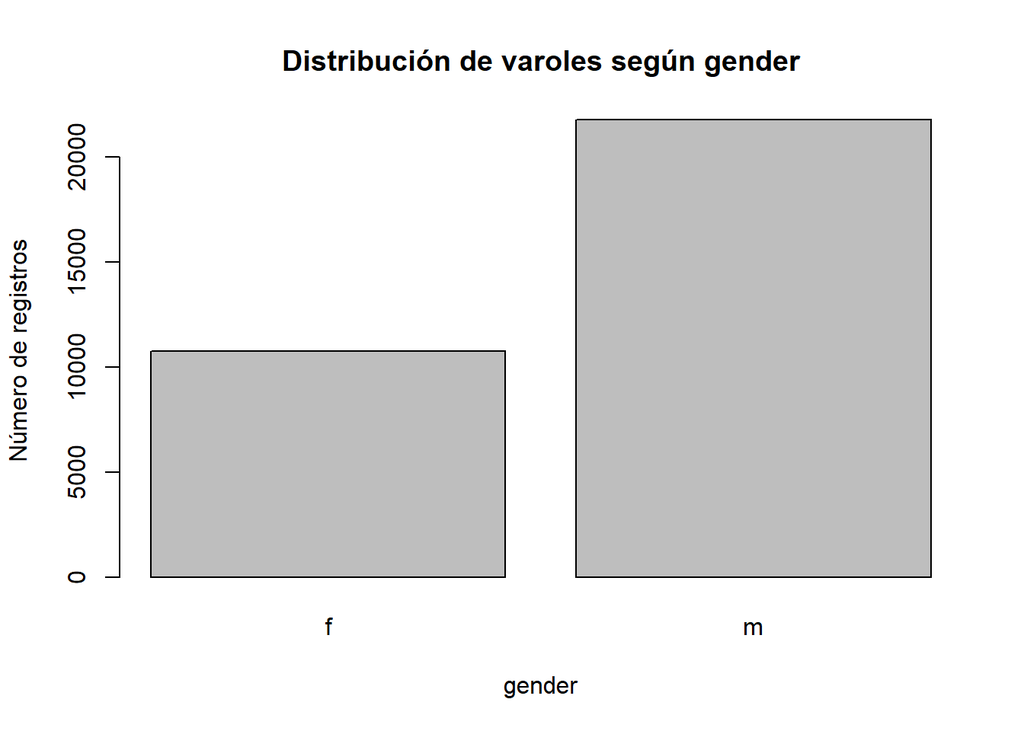

```r
plot(x=CensusIncomedatasetMod$gender, main ="Distribución de varoles según gender", xlab = "gender", ylab = "Número de registros")
```

# 5.- Normalización de los datos cuantitativos

## 5.1.- Edad

En este caso, la variable debe ser de tipo entero. Como actualmente es un factor, se convierte primero a tipo integer.

```r
CensusIncomedatasetMod$age <- as.integer(CensusIncomedatasetMod$age)
```

Se muestra a continuación un extracto del dataset para comprobar que, efectivamente, la variable *age* es de tipo entero.

```r
head(CensusIncomedatasetMod$age)
```

```
## [1] 34 22 37 12 21 33
```

## 5.2.- Educación

En este caso, al igual que enterior, la variable debe ser de tipo entero. Por lo tanto, se convierte a integer y se muestra un extracto de los datos para comprobar que se ha realizado correctamente.

```r
CensusIncomedatasetMod$education_num <- as.integer(CensusIncomedatasetMod$education_num)
head(CensusIncomedatasetMod$education_num)
```

```
## [1]  5 16 14  5  6 12
```

## 5.3.- Horas por semana

Si se observan los posibles valores de la variable **hours_per_wek** se puede ver que va acompañada de la métrica, es decir, de la letra h que indica que está medida en horas. Por lo tanto, en primer lugar, se elimina esta letra y los espacios en blanco que siguen a los números.

```r
CensusIncomedatasetMod$hours_per_week <- str_remove_all(CensusIncomedatasetMod$hours_per_week, "\\sh")
head(CensusIncomedatasetMod$hours_per_week)
```

```
## [1] "13,5" "40"   "40,5" "40"   "40,5" "16"
```

Una vez eliminada la letra h y los espacios en blanco se va a sustituir la coma por el punto, que es el separador de decimales en este caso.

```r
CensusIncomedatasetMod$hours_per_week <- str_replace_all(CensusIncomedatasetMod$hours_per_week, ",", "\\.")
head(CensusIncomedatasetMod$hours_per_week)
```

```
## [1] "13.5" "40"   "40.5" "40"   "40.5" "16"
```

Por último, se va a convertir en tipo numérico, puesto que actualmente es de tipo string (chr).

```r
CensusIncomedatasetMod$hours_per_week <- as.numeric(CensusIncomedatasetMod$hours_per_week)
head(CensusIncomedatasetMod$hours_per_week)
```

```
## [1] 13.5 40.0 40.5 40.0 40.5 16.0
```

## 5.4.- Income

En primer lugar, se observa el formato de esta variable y alguno de los posibles valores.

```r
head(CensusIncomedatasetMod$income)
```

```
## [1] 2000,3 Milers d'euros 51,67 Milers d'euros  50,08 Milers d'euros
## [4] 44,21 Milers d'euros  0,1 Milers d'euros    43,93 Milers d'euros
## 4101 Levels: 0,1 Milers d'euros 2000,3 Milers d'euros ... 68,37 Milers d'euros
```

Se observa que, al igual que en el caso anterior, esta variable va acompañada siempre del nombre de la unidad de medida. Por lo tanto, se va a extraer esta unidad de medida y comprobar si siempre es la misma o varía.

```r
unique(as.character(str_extract_all(CensusIncomedatasetMod$income, "\\s[aA-zZ](.+)")))
```

```
## [1] " Milers d'euros" " euros"
```

Se puede observar que tenemos datos tanto en euros como en miles de euros. Lo que se va a hacer a continuación, es eliminar la unidad de medida de la variable. Como se necesita saber cuales están en euros y cuales en miles de euros para pasarlos a la misma unidad, se va a colocar temporalmente la unidad de medida en una nueva columna.

```r
CensusIncomedatasetMod$incomeUnidad <- str_trim(as.character(str_extract(CensusIncomedatasetMod$income, "\\s[aA-zZ](.+)")))
CensusIncomedatasetMod$income <- str_remove_all(CensusIncomedatasetMod$income, "\\s[aA-zZ](.+)")
```

Ahora se va a reemplazar la , por el . y se convertirá la variable a numérica.

```r
CensusIncomedatasetMod$income <- as.numeric(str_replace_all(CensusIncomedatasetMod$income, ",", "\\."))
head(CensusIncomedatasetMod$income)
```

```
## [1] 2000.30   51.67   50.08   44.21    0.10   43.93
```

Ahora que la variable ya es numérica, podemos dividirla entre 1000 en aquellos casos que la unidad de medida sea euros.

```r
CensusIncomedatasetMod$income <- ifelse(CensusIncomedatasetMod$incomeUnidad == "euros", CensusIncomedatasetMod$income/1000, CensusIncomedatasetMod$income)
```

Por último, podemos eliminar la columna creada anteriormente con la unidad de medida, puesto que no aporta valor. Se muestra un resumen del dataset.

```r
CensusIncomedatasetMod <- CensusIncomedatasetMod[, !names(CensusIncomedatasetMod) %in% ("incomeUnidad")]
summary(CensusIncomedatasetMod)
```

```
##      CS_ID            age               workclass     education_num
##  CS1    :    1   Min.   : 1.0   Government   : 4349   Min.   : 1.000
##  CS10   :    1   1st Qu.:12.0   Other/Unknown: 1855   1st Qu.: 3.000
##  CS100  :    1   Median :21.0   Private      :22692   Median : 6.000
##  CS1000 :    1   Mean   :22.7   Self-Employed: 3657   Mean   : 8.867
##  CS10000:    1   3rd Qu.:32.0                         3rd Qu.:16.000
##  CS10001:    1   Max.   :66.0                         Max.   :16.000
##  (Other):32547
##  marital_status         relationship           occupation
##  D: 4442        Husband       :13192   Blue-Collar  :10060
##  M:15413        Not-in-family : 8303   Other/Unknown: 1850
##  S:10680        Other-relative:  981   Professional : 4139
##  W:  993        Own-child     : 5067   Sales        : 3649
##  X: 1025        Unmarried     : 3444   Service      : 5021
##                 Wife          : 1566   White-Collar : 7834
##
##                  race       gender    hours_per_week      income
##  Amer-Indian-Eskimo:  311   f:10767   Min.   : 1.00   Min.   :   0.10
##  Asian-Pac-Islander: 1039   m:21786   1st Qu.:40.00   1st Qu.:  43.22
##  Black             : 3123             Median :40.50   Median :  49.71
##  Other             :  271             Mean   :40.71   Mean   :  48.88
##  White             :27809             3rd Qu.:45.50   3rd Qu.:  54.32
##                                       Max.   :99.50   Max.   :2134.60
##
##           education_cat
##  postuniversitara: 2712
##  primaria        : 2644
##  secundaria      :12106
##  universitaria   :15091
##
##
##
```

# 6.- Valores atípicos

Se revisa si existen valores atípicos para las variables **age**, **education_num**, **hours_per_week** y **income**. Para ello, se realizan unos gráficos de cajas para analizar de manera visual los outliers.

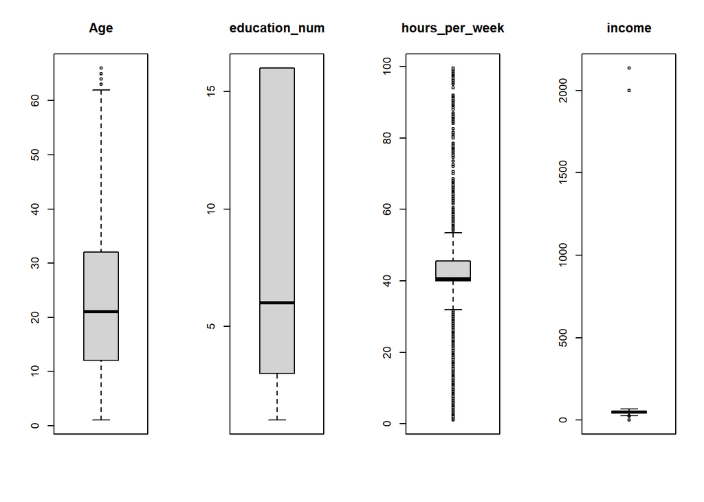

```r
par(mfrow = c(1, 4))
g_age <- boxplot(x=CensusIncomedatasetMod$age, main = "Age")
g_education_num <- boxplot(x=CensusIncomedatasetMod$education_num, main ="education_num")
g_hours_per_week <- boxplot(x=CensusIncomedatasetMod$hours_per_week, main = "hours_per_week")
g_income <- boxplot(x=CensusIncomedatasetMod$income, main = "income")
```

En los gráficos de cajas se observa que la variable **age** tiene valores atípicos elevados. En cuanto a la variable **education_num** no se encuentran valores anómalos para ella. Por otra parte, la variable **income** también tiene valores atípicos, elevados y demasiado bajos. Por último, en cuanto a la variable **hours_per_week** se observa que considera demasiados valores como outliers según el gráfico de cajas. En este último caso, como se indica en los datos del enunciado, se considerarán valores atípicos aquellos que sean superiores a 80 (80 horas por semana).

Una vez identificados los valores atípicos, se sustituyen por NA, para tratarlos en el próximo apartado.

```r
CensusIncomedatasetMod$age <- ifelse(CensusIncomedatasetMod$age %in% g_age$out, NA, CensusIncomedatasetMod$age)
CensusIncomedatasetMod$income <- ifelse(CensusIncomedatasetMod$income %in% g_income$out, NA, CensusIncomedatasetMod$income)
CensusIncomedatasetMod$hours_per_week <- ifelse(CensusIncomedatasetMod$hours_per_week > 80, NA, CensusIncomedatasetMod$hours_per_week)
summary(CensusIncomedatasetMod)
```

```
##      CS_ID            age                workclass     education_num
##  CS1    :    1   Min.   : 1.00   Government   : 4349   Min.   : 1.000
##  CS10   :    1   1st Qu.:12.00   Other/Unknown: 1855   1st Qu.: 3.000
##  CS100  :    1   Median :21.00   Private      :22692   Median : 6.000
##  CS1000 :    1   Mean   :22.58   Self-Employed: 3657   Mean   : 8.867
##  CS10000:    1   3rd Qu.:31.00                         3rd Qu.:16.000
##  CS10001:    1   Max.   :62.00                         Max.   :16.000
##  (Other):32547   NA's   :94
##  marital_status         relationship           occupation
##  D: 4442        Husband       :13192   Blue-Collar  :10060
##  M:15413        Not-in-family : 8303   Other/Unknown: 1850
##  S:10680        Other-relative:  981   Professional : 4139
##  W:  993        Own-child     : 5067   Sales        : 3649
##  X: 1025        Unmarried     : 3444   Service      : 5021
##                 Wife          : 1566   White-Collar : 7834
##
##                  race       gender    hours_per_week      income
##  Amer-Indian-Eskimo:  311   f:10767   Min.   : 1.00   Min.   :26.96
##  Asian-Pac-Islander: 1039   m:21786   1st Qu.:40.00   1st Qu.:43.23
##  Black             : 3123             Median :40.50   Median :49.72
##  Other             :  271             Mean   :40.29   Mean   :48.76
##  White             :27809             3rd Qu.:45.00   3rd Qu.:54.32
##                                       Max.   :80.00   Max.   :68.37
##                                       NA's   :277     NA's   :8
##           education_cat
##  postuniversitara: 2712
##  primaria        : 2644
##  secundaria      :12106
##  universitaria   :15091
##
##
##
```

# 7.- Imputación de valores

Existen valores perdidos en las variables **age**, **hours_per_week** e **income**. En primer lugar, se imputarán los valores de **age** por media aritmética. Es decir, los valores perdidos se sustituirán por la media de los valores válidos. Para ello, primero sacaremos los identificadores de estos resgistros con valores perdidos en la edad, para ver después de la imputación el resultado.

```r
Age_na <- filter(CensusIncomedatasetMod, is.na(age))
head(Age_na)
```

```
##    CS_ID age     workclass education_num marital_status  relationship
## 1   CS74  NA       Private             2              M Not-in-family
## 2  CS316  NA Self-Employed             2              M Not-in-family
## 3  CS978  NA       Private            16              W       Husband
## 4 CS1951  NA    Government            16              M       Husband
## 5 CS2592  NA Self-Employed            16              S Not-in-family
## 6 CS2684  NA    Government             5              M       Husband
##     occupation  race gender hours_per_week income education_cat
## 1 Professional White      m           20.5  52.65 universitaria
## 2        Sales White      m           40.5  52.02 universitaria
## 3      Service Black      f           40.0  39.99    secundaria
## 4 White-Collar White      m            6.5  61.53    secundaria
## 5  Blue-Collar White      m           20.0  46.29    secundaria
## 6 White-Collar White      m           15.0  60.48 universitaria
```

```r
CensusIncomedatasetMod$age <- ifelse(is.na(CensusIncomedatasetMod$age), mean(na.omit(CensusIncomedatasetMod$age)), CensusIncomedatasetMod$age )
summary(CensusIncomedatasetMod)
```

```
##      CS_ID            age                workclass     education_num
##  CS1    :    1   Min.   : 1.00   Government   : 4349   Min.   : 1.000
##  CS10   :    1   1st Qu.:12.00   Other/Unknown: 1855   1st Qu.: 3.000
##  CS100  :    1   Median :21.00   Private      :22692   Median : 6.000
##  CS1000 :    1   Mean   :22.58   Self-Employed: 3657   Mean   : 8.867
##  CS10000:    1   3rd Qu.:31.00                         3rd Qu.:16.000
##  CS10001:    1   Max.   :62.00                         Max.   :16.000
##  (Other):32547
##  marital_status         relationship           occupation
##  D: 4442        Husband       :13192   Blue-Collar  :10060
##  M:15413        Not-in-family : 8303   Other/Unknown: 1850
##  S:10680        Other-relative:  981   Professional : 4139
##  W:  993        Own-child     : 5067   Sales        : 3649
##  X: 1025        Unmarried     : 3444   Service      : 5021
##                 Wife          : 1566   White-Collar : 7834
##
##                  race       gender    hours_per_week      income
##  Amer-Indian-Eskimo:  311   f:10767   Min.   : 1.00   Min.   :26.96
##  Asian-Pac-Islander: 1039   m:21786   1st Qu.:40.00   1st Qu.:43.23
##  Black             : 3123             Median :40.50   Median :49.72
##  Other             :  271             Mean   :40.29   Mean   :48.76
##  White             :27809             3rd Qu.:45.00   3rd Qu.:54.32
##                                       Max.   :80.00   Max.   :68.37
##                                       NA's   :277     NA's   :8
##           education_cat
##  postuniversitara: 2712
##  primaria        : 2644
##  secundaria      :12106
##  universitaria   :15091
##
##
##
```

Vemos en el resumen que ya no existen valores perdidos para la variable. Vamos a observar alguno de los valores asignados:

```r
head(filter(CensusIncomedatasetMod,CS_ID %in% Age_na$CS_ID ))
```

```
##    CS_ID      age     workclass education_num marital_status  relationship
## 1   CS74 22.58049       Private             2              M Not-in-family
## 2  CS316 22.58049 Self-Employed             2              M Not-in-family
## 3  CS978 22.58049       Private            16              W       Husband
## 4 CS1951 22.58049    Government            16              M       Husband
## 5 CS2592 22.58049 Self-Employed            16              S Not-in-family
## 6 CS2684 22.58049    Government             5              M       Husband
##     occupation  race gender hours_per_week income education_cat
## 1 Professional White      m           20.5  52.65 universitaria
## 2        Sales White      m           40.5  52.02 universitaria
## 3      Service Black      f           40.0  39.99    secundaria
## 4 White-Collar White      m            6.5  61.53    secundaria
## 5  Blue-Collar White      m           20.0  46.29    secundaria
## 6 White-Collar White      m           15.0  60.48 universitaria
```

Se observa que el valor que toma la variable es el mismo, siempre la media. Ahora vamos a imputar la variable **income**. En este caso, se usará la media aritmética de los registros del mismo sexo. se van a extraer en primer lugar estos registros para realizar después la comparación con los datos imputados.

```r
Income_na <- filter(CensusIncomedatasetMod, is.na(income))
```

```r
CensusIncomedatasetMod$income <- ifelse(is.na(CensusIncomedatasetMod$income) & CensusIncomedatasetMod$gender == "m", mean(na.omit(filter(CensusIncomedatasetMod, gender == "m")$income)),
                                 ifelse(is.na(CensusIncomedatasetMod$income) & CensusIncomedatasetMod$gender == "f", mean(na.omit(filter(CensusIncomedatasetMod, gender == "f")$income)), CensusIncomedatasetMod$income))
summary(CensusIncomedatasetMod)
```

```
##      CS_ID            age                workclass     education_num
##  CS1    :    1   Min.   : 1.00   Government   : 4349   Min.   : 1.000
##  CS10   :    1   1st Qu.:12.00   Other/Unknown: 1855   1st Qu.: 3.000
##  CS100  :    1   Median :21.00   Private      :22692   Median : 6.000
##  CS1000 :    1   Mean   :22.58   Self-Employed: 3657   Mean   : 8.867
##  CS10000:    1   3rd Qu.:31.00                         3rd Qu.:16.000
##  CS10001:    1   Max.   :62.00                         Max.   :16.000
##  (Other):32547
##  marital_status         relationship           occupation
##  D: 4442        Husband       :13192   Blue-Collar  :10060
##  M:15413        Not-in-family : 8303   Other/Unknown: 1850
##  S:10680        Other-relative:  981   Professional : 4139
##  W:  993        Own-child     : 5067   Sales        : 3649
##  X: 1025        Unmarried     : 3444   Service      : 5021
##                 Wife          : 1566   White-Collar : 7834
##
##                  race       gender    hours_per_week      income
##  Amer-Indian-Eskimo:  311   f:10767   Min.   : 1.00   Min.   :26.96
##  Asian-Pac-Islander: 1039   m:21786   1st Qu.:40.00   1st Qu.:43.22
##  Black             : 3123             Median :40.50   Median :49.71
##  Other             :  271             Mean   :40.29   Mean   :48.76
##  White             :27809             3rd Qu.:45.00   3rd Qu.:54.32
##                                       Max.   :80.00   Max.   :68.37
##                                       NA's   :277
##           education_cat
##  postuniversitara: 2712
##  primaria        : 2644
##  secundaria      :12106
##  universitaria   :15091
##
##
##
```

Observamos que la variable **income** ya no tiene valores perdidos. Veamos que valores muestra ahora en esos casos.

```r
filter(CensusIncomedatasetMod, CS_ID %in% Income_na$CS_ID)
```

```
##     CS_ID age     workclass education_num marital_status  relationship
## 1     CS1  34 Self-Employed             5              M Not-in-family
## 2     CS5  21       Private             6              M          Wife
## 3     CS7  36 Self-Employed            16              M Not-in-family
## 4  CS3555   1 Other/Unknown            14              S     Unmarried
## 5  CS7080   2       Private            14              S       Husband
## 6 CS16743   1 Other/Unknown            13              S Not-in-family
## 7 CS20551   5 Other/Unknown             2              S     Own-child
## 8 CS32075  11 Other/Unknown             6              S          Wife
##      occupation  race gender hours_per_week   income    education_cat
## 1  White-Collar White      m           13.5 52.32484    universitaria
## 2  White-Collar White      f           40.5 41.53625 postuniversitara
## 3  White-Collar White      m           45.0 52.32484       secundaria
## 4 Other/Unknown Other      f           20.5 41.53625       secundaria
## 5         Sales Other      f           20.0 41.53625       secundaria
## 6 Other/Unknown Other      f           20.0 41.53625         primaria
## 7 Other/Unknown Other      f           40.0 41.53625    universitaria
## 8 Other/Unknown Other      f           40.0 41.53625 postuniversitara
```

Vemos como cambia el valor imputado dependiendo del valor de la variable **gender**. Por último, se van a imputar los valores perdidos de la variable **hours_per_week** mediante vecinos más cercanos, usando la distancia de Gower, considerando en el címputo de los vecinos cercanos las variables cuantitativas: **age**, **income**, **education_num**. Para realizar la imputación también se tendrá en cuenta el género. Se extraen, como siempre, los registros con valores nulos en la variable para su posterior comparación.

```r
Hours_per_week_na <- filter(CensusIncomedatasetMod, is.na(hours_per_week))
head(Hours_per_week_na)
```

```
##    CS_ID age     workclass education_num marital_status  relationship
## 1   CS10  21       Private             2              M       Husband
## 2  CS272  34 Self-Employed             6              M     Own-child
## 3  CS935  21       Private            16              M       Husband
## 4 CS1066  19       Private             7              M     Own-child
## 5 CS1172   9       Private             6              M Not-in-family
## 6 CS1200  29    Government            16              M       Husband
##     occupation  race gender hours_per_week income    education_cat
## 1 White-Collar Black      m             NA  49.72    universitaria
## 2  Blue-Collar White      m             NA  57.71 postuniversitara
## 3  Blue-Collar White      m             NA  56.85       secundaria
## 4 Professional White      m             NA  54.15 postuniversitara
## 5  Blue-Collar White      m             NA  60.74 postuniversitara
## 6 White-Collar Black      m             NA  55.29       secundaria
```

```r
mujeres <- kNN(filter(CensusIncomedatasetMod, gender == "f"), variable = "hours_per_week", metric = Gower, k=11, dist_var = c("age", "income", "education_num"))
hombres <- kNN(filter(CensusIncomedatasetMod, gender == "m"), variable = "hours_per_week", metric = Gower, k=11, dist_var = c("age", "income", "education_num"))
CensusIncomedatasetMod <- bind_rows(mujeres, hombres)
summary(CensusIncomedatasetMod)
```

```
##      CS_ID            age                workclass     education_num
##  CS1    :    1   Min.   : 1.00   Government   : 4349   Min.   : 1.000
##  CS10   :    1   1st Qu.:12.00   Other/Unknown: 1855   1st Qu.: 3.000
##  CS100  :    1   Median :21.00   Private      :22692   Median : 6.000
##  CS1000 :    1   Mean   :22.58   Self-Employed: 3657   Mean   : 8.867
##  CS10000:    1   3rd Qu.:31.00                         3rd Qu.:16.000
##  CS10001:    1   Max.   :62.00                         Max.   :16.000
##  (Other):32547
##  marital_status         relationship           occupation
##  D: 4442        Husband       :13192   Blue-Collar  :10060
##  M:15413        Not-in-family : 8303   Other/Unknown: 1850
##  S:10680        Other-relative:  981   Professional : 4139
##  W:  993        Own-child     : 5067   Sales        : 3649
##  X: 1025        Unmarried     : 3444   Service      : 5021
##                 Wife          : 1566   White-Collar : 7834
##
##                  race       gender    hours_per_week      income
##  Amer-Indian-Eskimo:  311   f:10767   Min.   : 1.00   Min.   :26.96
##  Asian-Pac-Islander: 1039   m:21786   1st Qu.:40.00   1st Qu.:43.22
##  Black             : 3123             Median :40.50   Median :49.71
##  Other             :  271             Mean   :40.31   Mean   :48.76
##  White             :27809             3rd Qu.:45.00   3rd Qu.:54.32
##                                       Max.   :80.00   Max.   :68.37
##
##           education_cat   hours_per_week_imp
##  postuniversitara: 2712   Mode :logical
##  primaria        : 2644   FALSE:32276
##  secundaria      :12106   TRUE :277
##  universitaria   :15091
##
##
##
```

Vamos a observar los valores que toma la variable.

```r
head(filter(CensusIncomedatasetMod, CS_ID %in% Hours_per_week_na$CS_ID))
```

```
##    CS_ID age workclass education_num marital_status  relationship   occupation
## 1 CS1272  12   Private             4              S       Husband      Service
## 2 CS2015  15   Private             7              S       Husband Professional
## 3 CS4294  12   Private             7              S Not-in-family Professional
## 4 CS4348  24   Private             2              D     Unmarried  Blue-Collar
## 5 CS5432  28   Private             7              D          Wife Professional
## 6 CS5489  25   Private             2              D       Husband White-Collar
##                 race gender hours_per_week income    education_cat
## 1              White      f           40.0  41.18    universitaria
## 2              White      f           45.5  41.42 postuniversitara
## 3              White      f           40.5  38.55 postuniversitara
## 4 Amer-Indian-Eskimo      f           40.0  41.34    universitaria
## 5              White      f           40.5  44.44 postuniversitara
## 6              White      f           40.0  43.92    universitaria
##   hours_per_week_imp
## 1               TRUE
## 2               TRUE
## 3               TRUE
## 4               TRUE
## 5               TRUE
## 6               TRUE
```

# 8.- Estudio descriptivo

## 8.1.- Funciones de media robusta

Se va a implementar una función que, dado un vector con datos numéricos, calcule la media recortada y otra que calcule la media Winsor.

```r
media.recortada <- function( x, perc=0.05){
   y <- sort(x)
   longitud <- length(x)
   quitar <- round(longitud*perc)
   z = head(y, -quitar)
   x = tail(z, -quitar)
   media = mean(x)
   return(media)
}
```

Para comprobar si funciona se va a realizar una comparación entre la función implementada y la función de R mean con el parámetro trim con la variable **age** del dataset.

```r
Funcion_r <- mean(CensusIncomedatasetMod$age, trim = 0.05)
Funcion_implementada <- media.recortada(CensusIncomedatasetMod$age)
Funcion_r
```

```
## [1] 21.98254
```

```r
Funcion_implementada
```

```
## [1] 21.9823
```

```r
media.winsor <- function( x, perc=0.05){
  y <- sort(x)
  longitud <- length(x)
  quitar <- round(longitud*perc)
  z = head(y, -quitar)
  x = tail(z, -quitar)
  maximo = max(x)
  minimo = min(x)
  if (quitar > 0){
    i <- 1
    while(i<=quitar){
      x = c(x, maximo)
      x = c(x, minimo)
      i <- i+1;
    }
  }
  media = mean(x)
  return(media)
}
```

Vamos a comprobar que funciona comparando el resultado con la función de R.

```r
Funcion_implementada <- media.winsor(CensusIncomedatasetMod$age)
Funcion_implementada
```

```
## [1] 22.33415
```

```r
Funcion_r <- winsor.mean(CensusIncomedatasetMod$age, trim=0.05)
Funcion_r
```

```
## [1] 22.33415
```

Se observa el mismo resultado con nuestra implementación que con la función de R, por lo que damos la función por válida.

## 8.2.- Estudio descriptivo de las variables cuantitativas

En primer lugar, se va a representar la distribución de estas variables de manera gráfica.

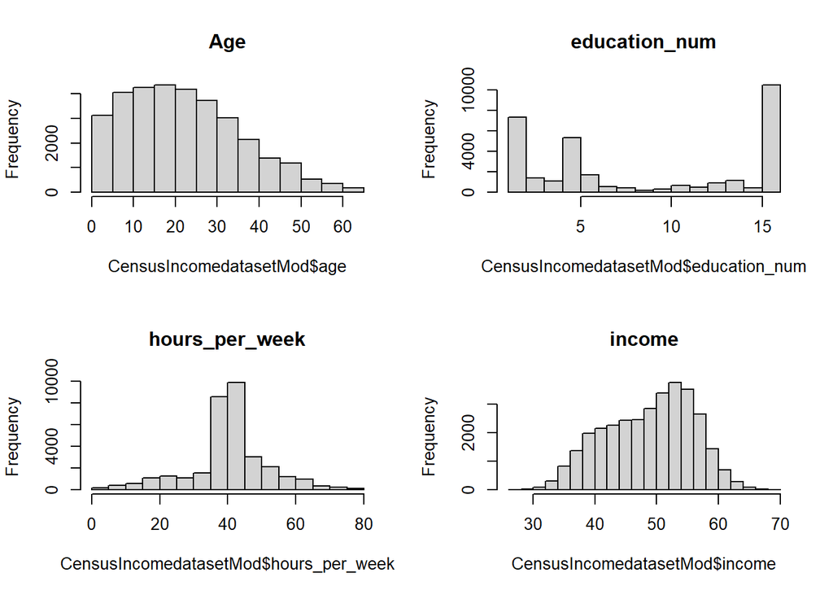

```r
par(mfrow = c(2,2))
hist(x=CensusIncomedatasetMod$age, main = "Age")
hist(x=CensusIncomedatasetMod$education_num, main ="education_num")
hist(x=CensusIncomedatasetMod$hours_per_week, main = "hours_per_week")
hist(x=CensusIncomedatasetMod$income, main = "income")
```

Ahora se va a montar una tabla con medidades de tendencia central y dispersión, robustas y no robustas.

```r
Variable <- c("Age", "Income", "Education_num", "hours_per_week")
Media_aritmetica <- c(mean(CensusIncomedatasetMod$age), mean(CensusIncomedatasetMod$income), mean(CensusIncomedatasetMod$education_num), mean(CensusIncomedatasetMod$hours_per_week))
Mediana <- c(median(CensusIncomedatasetMod$age), median(CensusIncomedatasetMod$income), median(CensusIncomedatasetMod$education_num), median(CensusIncomedatasetMod$hours_per_week))
Media_recortada <- c(media.recortada(CensusIncomedatasetMod$age), media.recortada(CensusIncomedatasetMod$income), media.recortada(CensusIncomedatasetMod$education_num),      media.recortada(CensusIncomedatasetMod$hours_per_week))
Media_winsor <- c(media.winsor(CensusIncomedatasetMod$age), media.winsor(CensusIncomedatasetMod$income), media.winsor(CensusIncomedatasetMod$education_num), media.winsor(CensusIncomedatasetMod$hours_per_week))
Desviacion_estandar <- c(sd(CensusIncomedatasetMod$age), sd(CensusIncomedatasetMod$income), sd(CensusIncomedatasetMod$education_num), sd(CensusIncomedatasetMod$hours_per_week))
Rango_intercuartilico <- c(IQR(CensusIncomedatasetMod$age), IQR(CensusIncomedatasetMod$income), IQR(CensusIncomedatasetMod$education_num), IQR(CensusIncomedatasetMod$hours_per_week))
Desviacion_absoluta_respecto_a_mediana <- c(mad(CensusIncomedatasetMod$age), mad(CensusIncomedatasetMod$income), mad(CensusIncomedatasetMod$education_num), mad(CensusIncomedatasetMod$hours_per_week))
tabla <- data.frame(cbind(Variable, Media_aritmetica, Mediana, Media_recortada, Media_winsor, Desviacion_estandar, Rango_intercuartilico, Desviacion_absoluta_respecto_a_mediana))
knitr::kable(tabla)
```

| Variable | Media_aritmetica | Mediana | Media_recortada | Media_winsor | Desviacion_estandar | Rango_intercuartilico | Desviacion_absoluta_respecto_a_mediana |
| --- | --- | --- | --- | --- | --- | --- | --- |
| Age | 22.5804861517607 | 21 | 21.9823041846696 | 22.3341494086034 | 13.6611362231555 | 19 | 14.826 |
| Income | 48.7564822651373 | 49.71 | 48.8571095053082 | 48.7608778661572 | 7.08967835690592 | 11.1 | 7.902258 |
| Education_num | 8.8667096734556 | 6 | 8.85360275796157 | 8.86824563020305 | 5.87087298316471 | 13 | 5.9304 |
| hours_per_week | 40.3066384050625 | 40.5 | 40.5166569955968 | 40.3899640586121 | 11.4727867233866 | 5 | 4.4478 |

# 9.- Archivo final

Una vez terminado el preprocesado de datos, se exporta el fichero final.

```r
write.csv(CensusIncomedatasetMod,"./CesusIncome_clean.csv")
```